# 4RTNI

# Sup. Cerebellar Peduncle MD

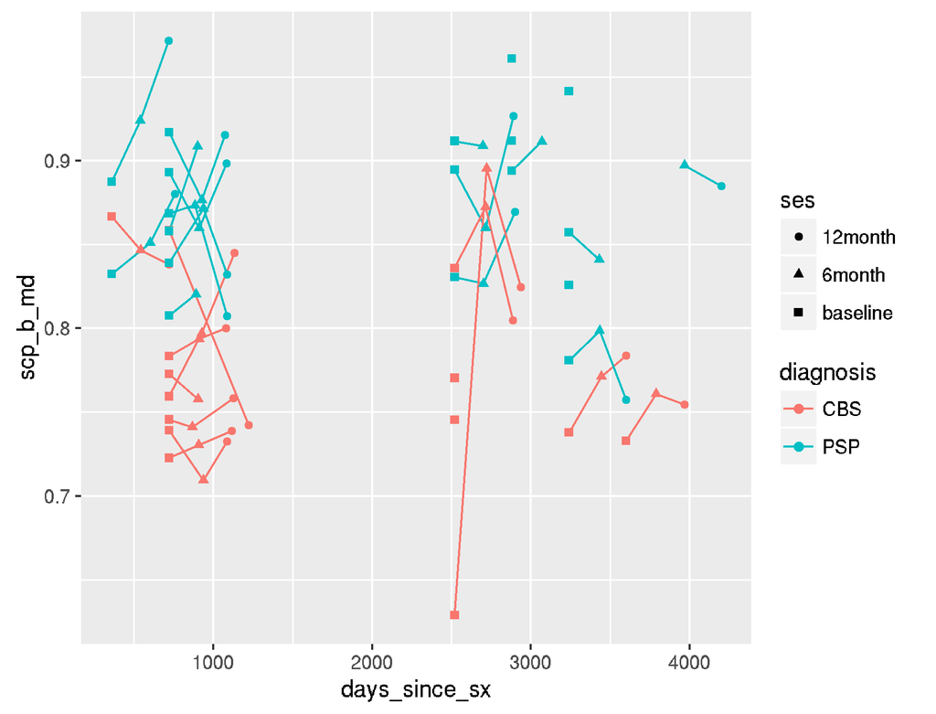

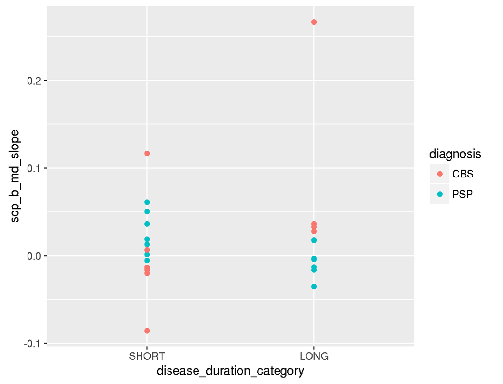

t.test for SHORT vs LONG group diff in slope among CBS: p=0.1993288

**t.test for SHORT vs LONG group diff in slope among PSP: p=0.02563614**

# Sup. Cerebellar Peduncle FA

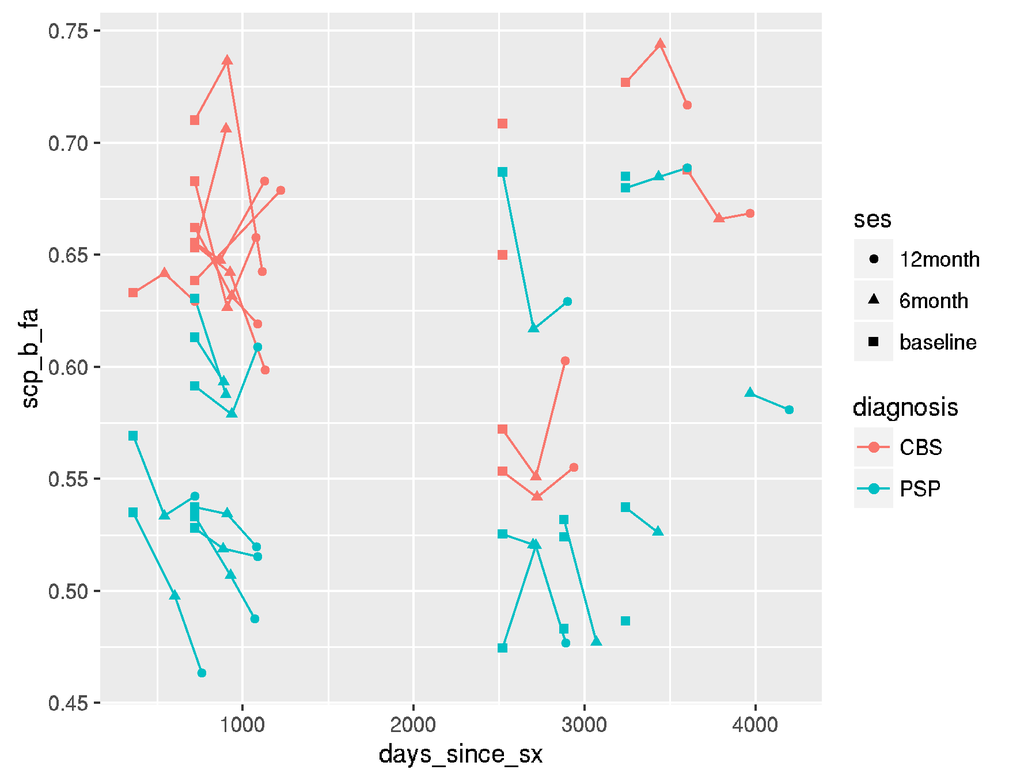

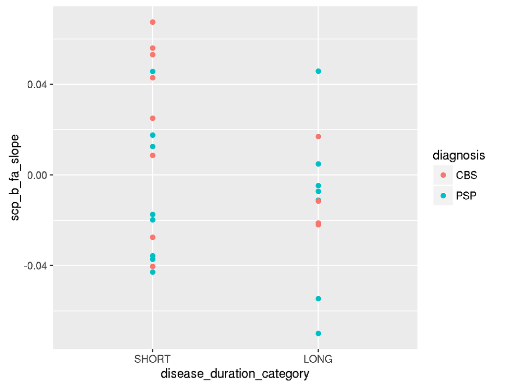

t.test for SHORT vs LONG group diff in slope among CBS: p=0.08089604

t.test for SHORT vs LONG group diff in slope among PSP: p=0.8234589

# Precentral+Postcentral Grey Matter Volume

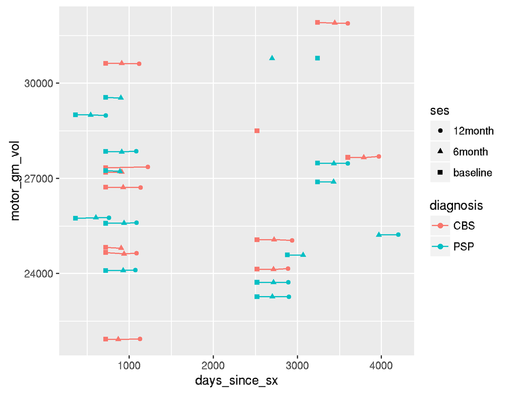

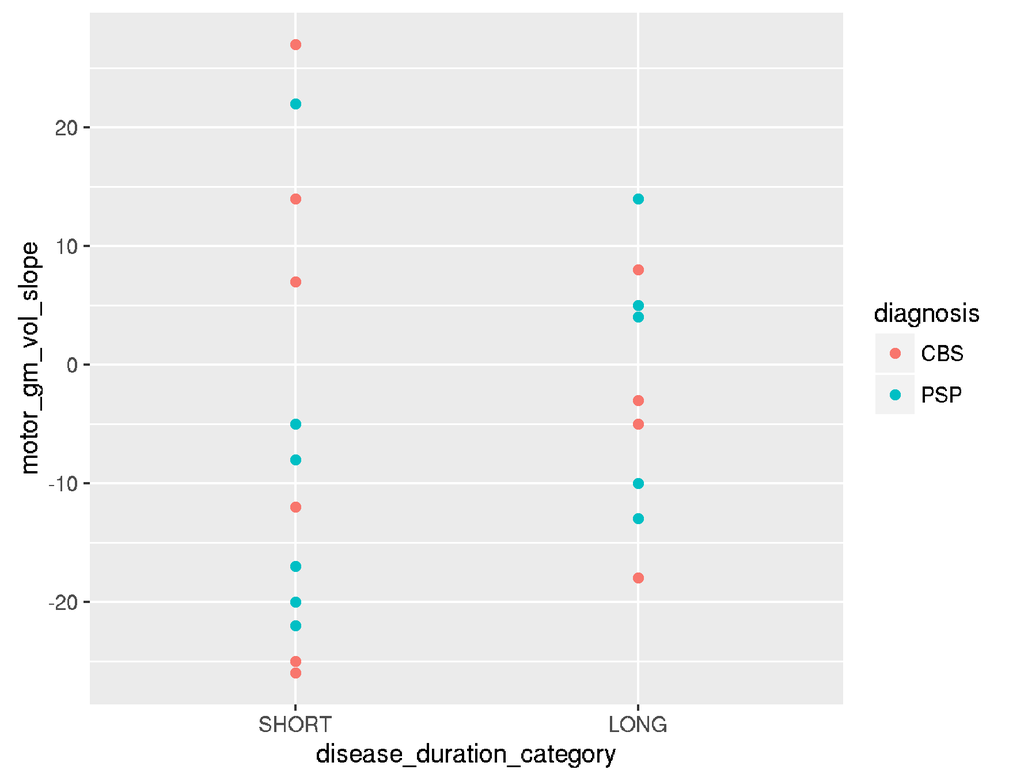

t.test for SHORT vs LONG group diff in slope among CBS: p=0.7271488

t.test for SHORT vs LONG group diff in slope among PSP: p=0.2285493

# Precentral+Postcentral White Matter Volume

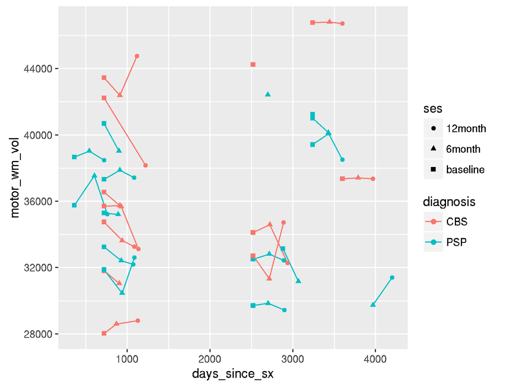

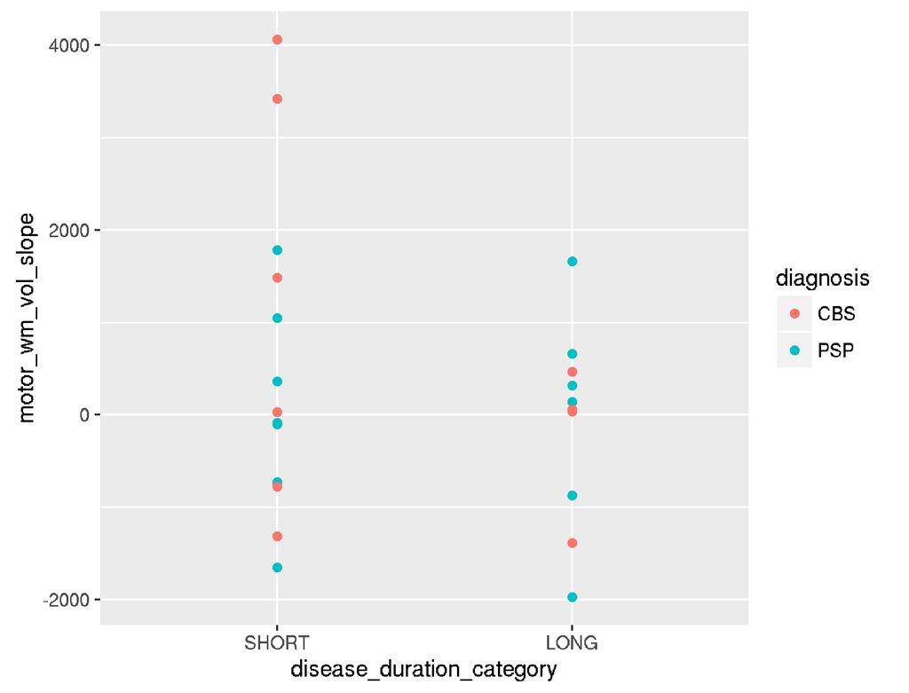

t.test for SHORT vs LONG group diff in slope among CBS: p=0.2670875

t.test for SHORT vs LONG group diff in slope among PSP: p=0.8842476

# Midbrain Volume

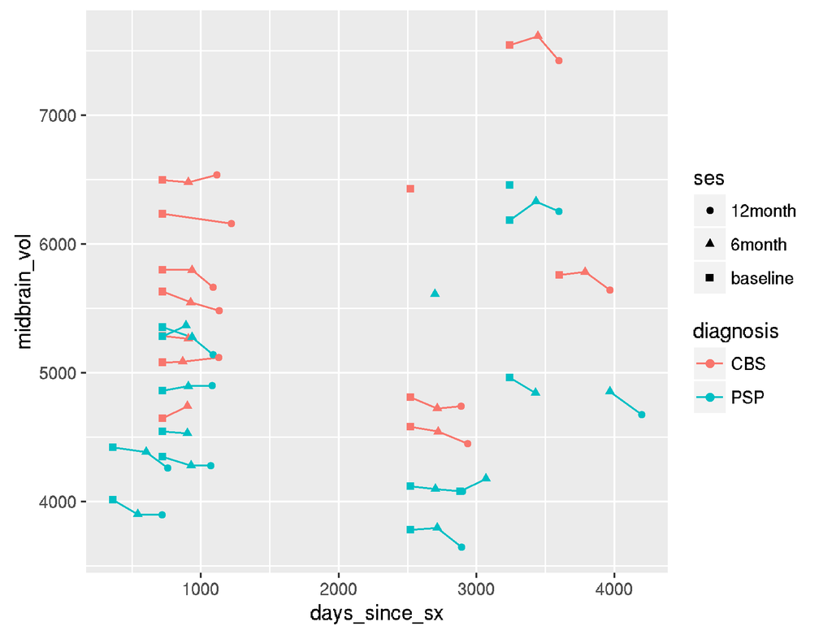

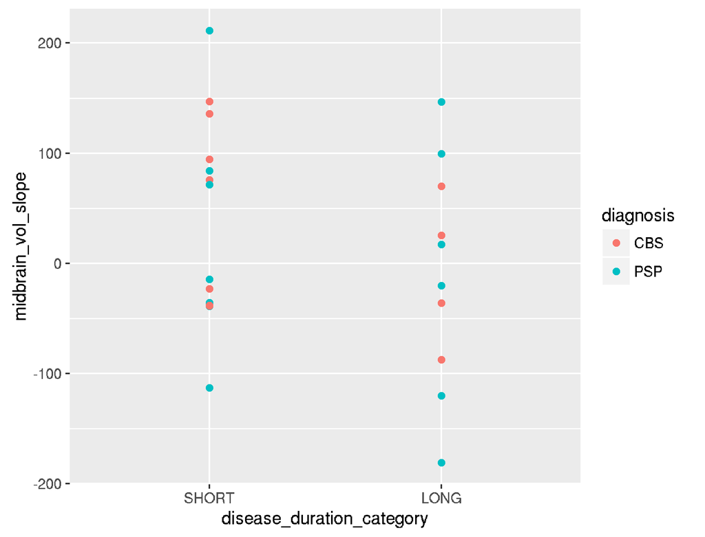

t.test for SHORT vs LONG group diff in slope among CBS: p=0.2529855

t.test for SHORT vs LONG group diff in slope among PSP: p=0.6220899

# Total Grey Matter Volume

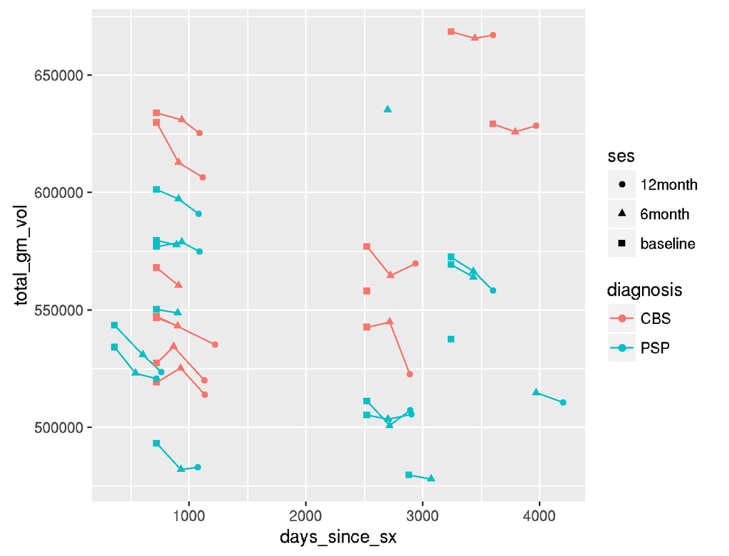

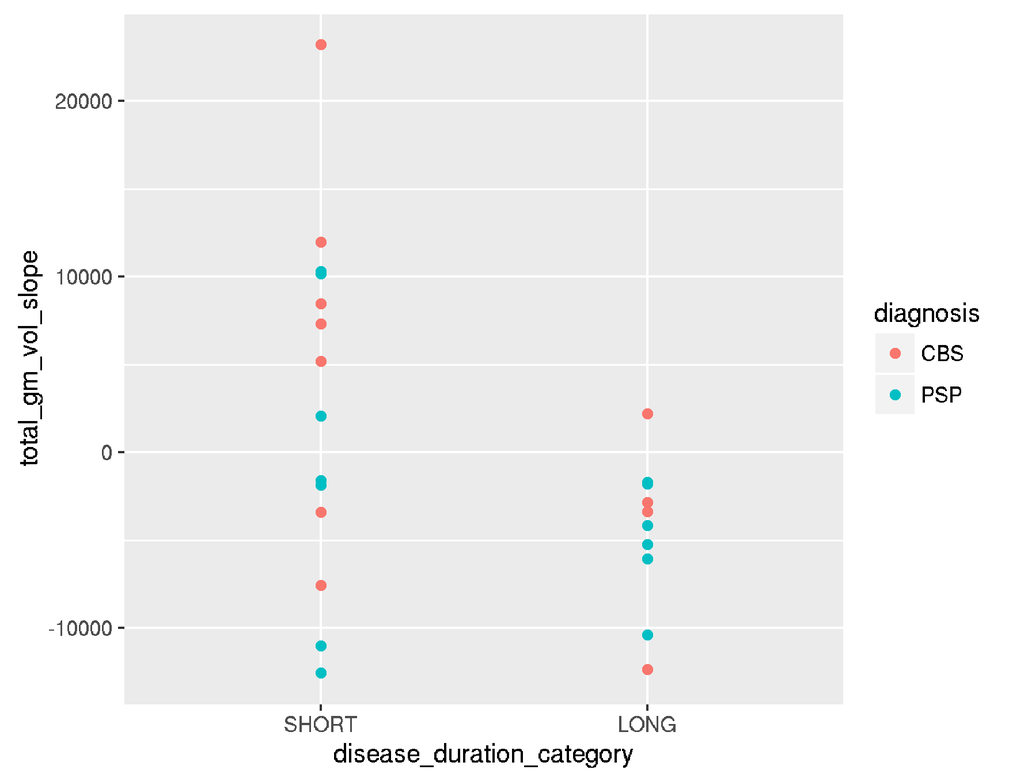

t.test for SHORT vs LONG group diff in slope among CBS: p=0.05866801

t.test for SHORT vs LONG group diff in slope among PSP: p=0.2838614

# Total White Matter Volume

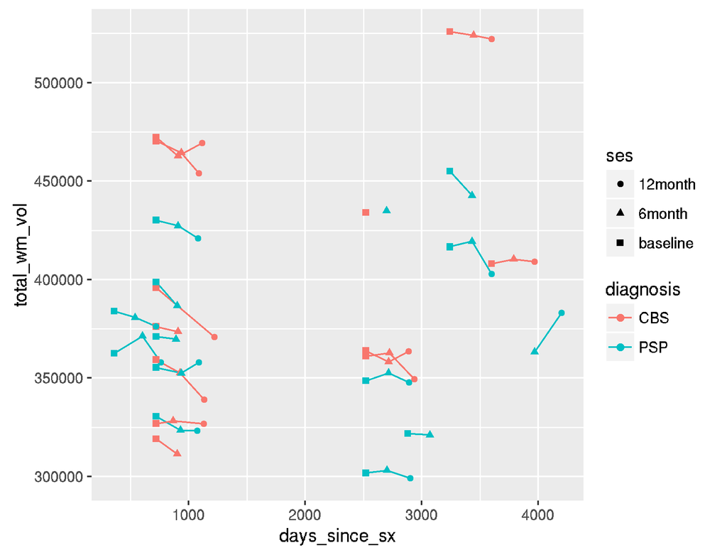

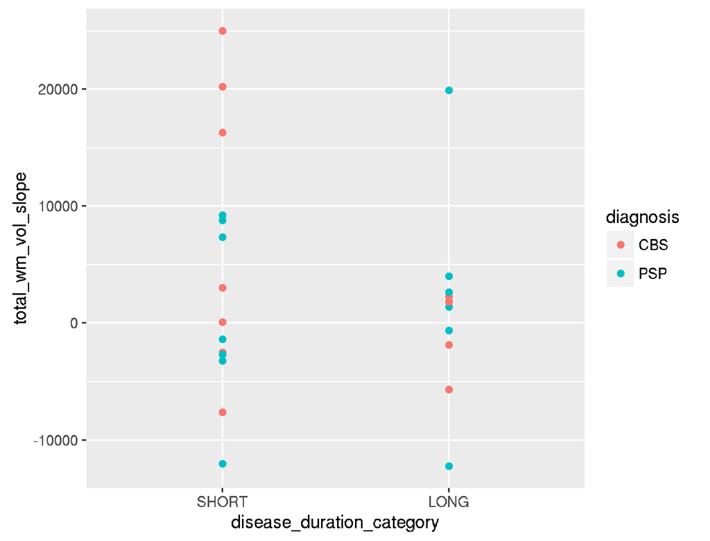

t.test for SHORT vs LONG group diff in slope among CBS: p=0.1302069

t.test for SHORT vs LONG group diff in slope among PSP: p=0.7562565

# Precentral FA

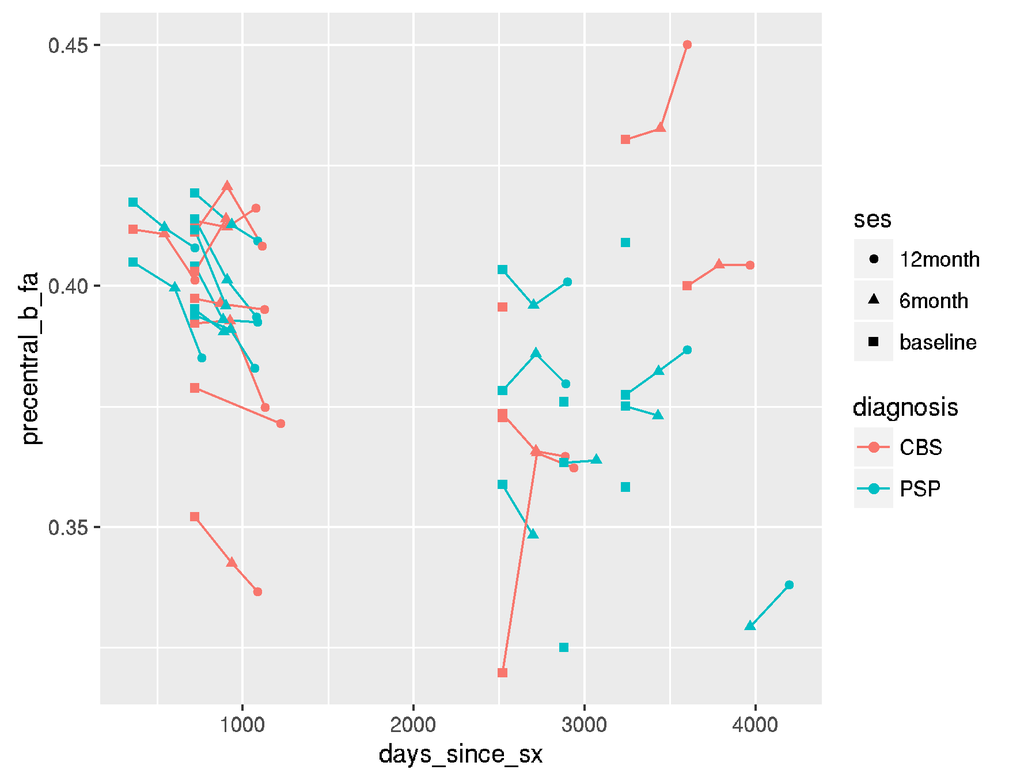

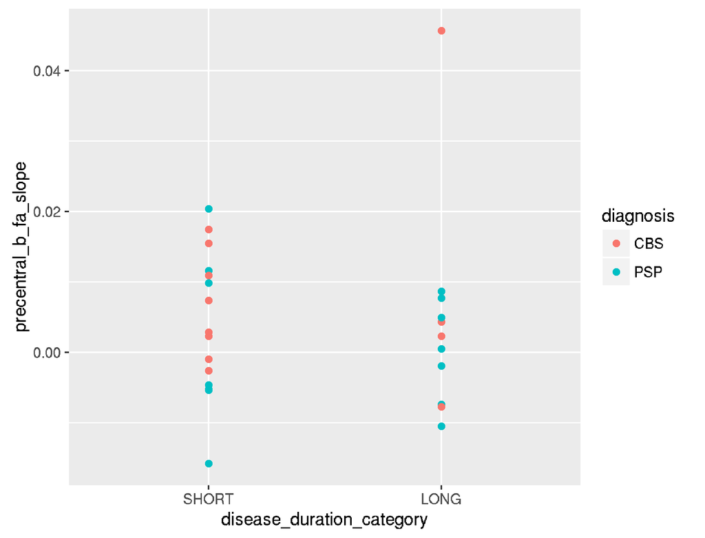

t.test for SHORT vs LONG group diff in slope among CBS: p=0.7295011

t.test for SHORT vs LONG group diff in slope among PSP: p=0.6442524

# Precentral MD

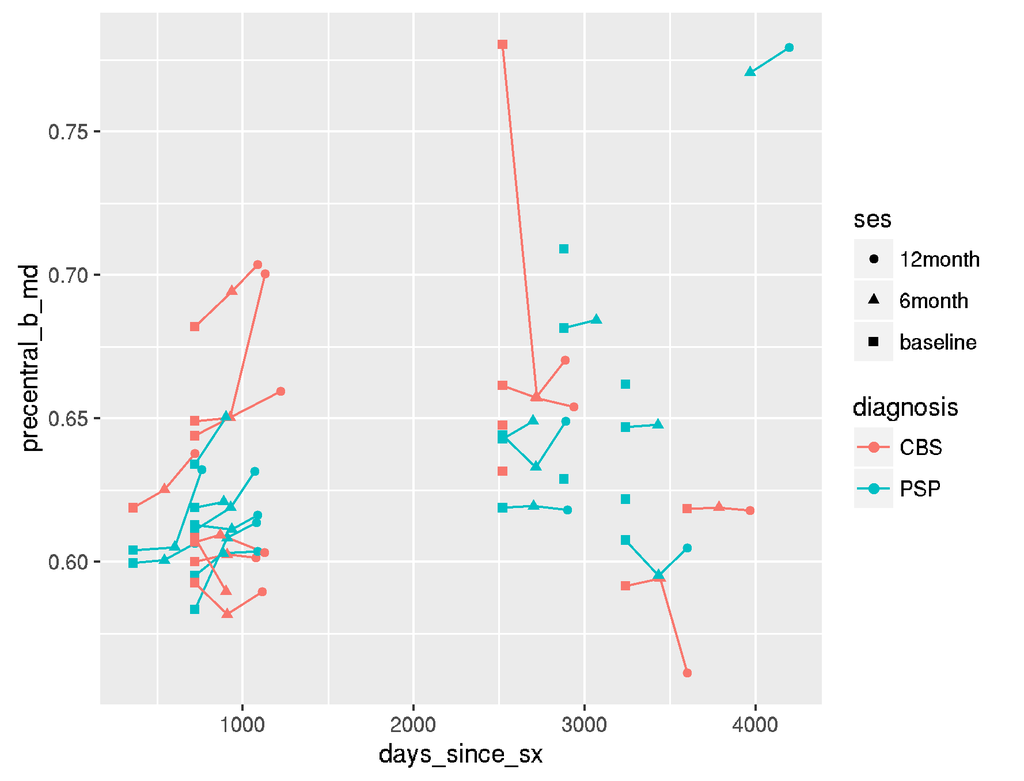

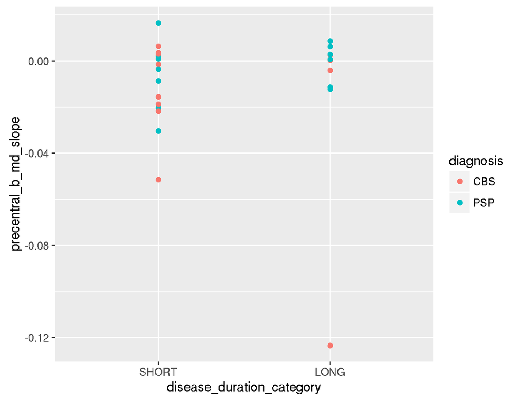

t.test for SHORT vs LONG group diff in slope among CBS: p=0.5825604

t.test for SHORT vs LONG group diff in slope among PSP: p=0.45385

# Superior Cerebellar Peduncle AD

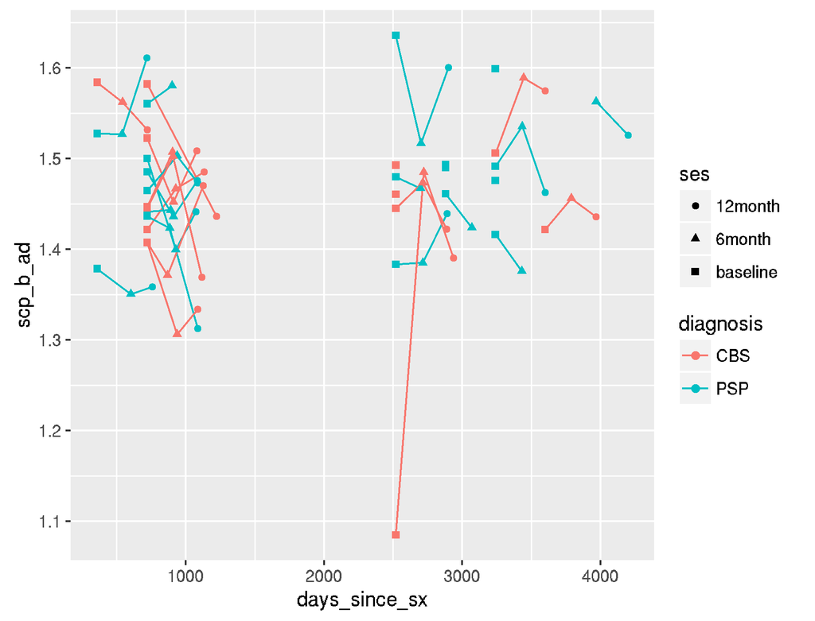

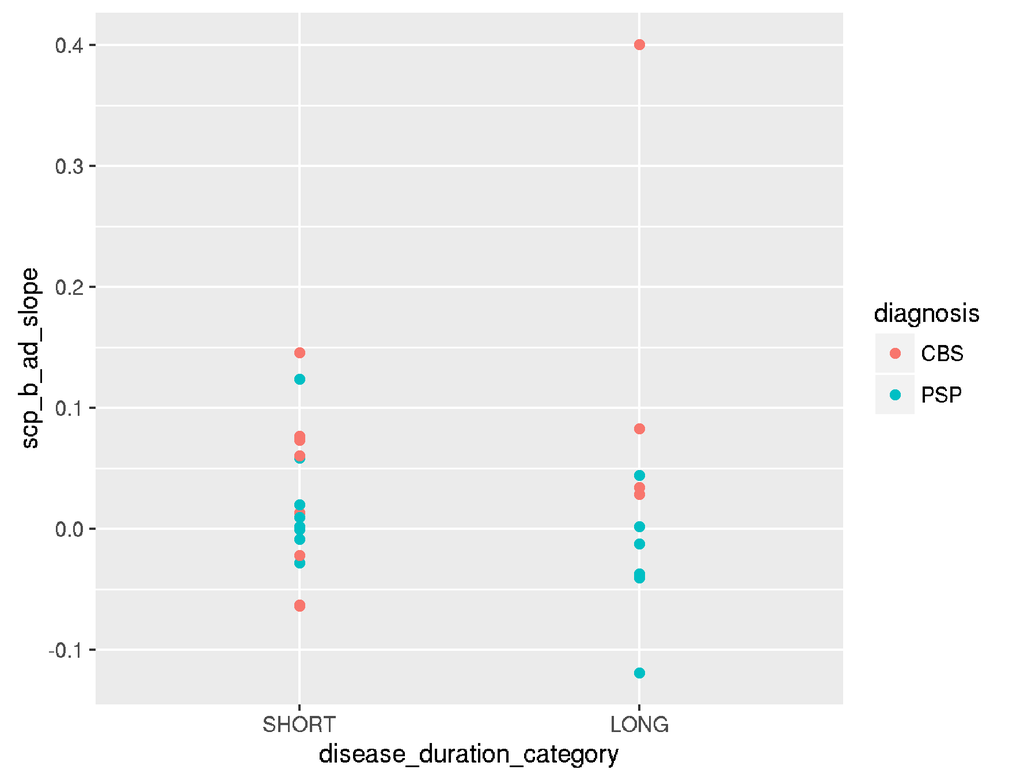

t.test for SHORT vs LONG group diff in slope among CBS: p=0.3125972

t.test for SHORT vs LONG group diff in slope among PSP: p=0.06862216

# Superior Cerebellar Peduncle RD

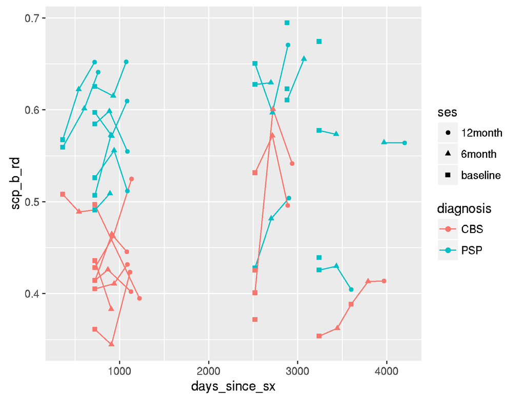

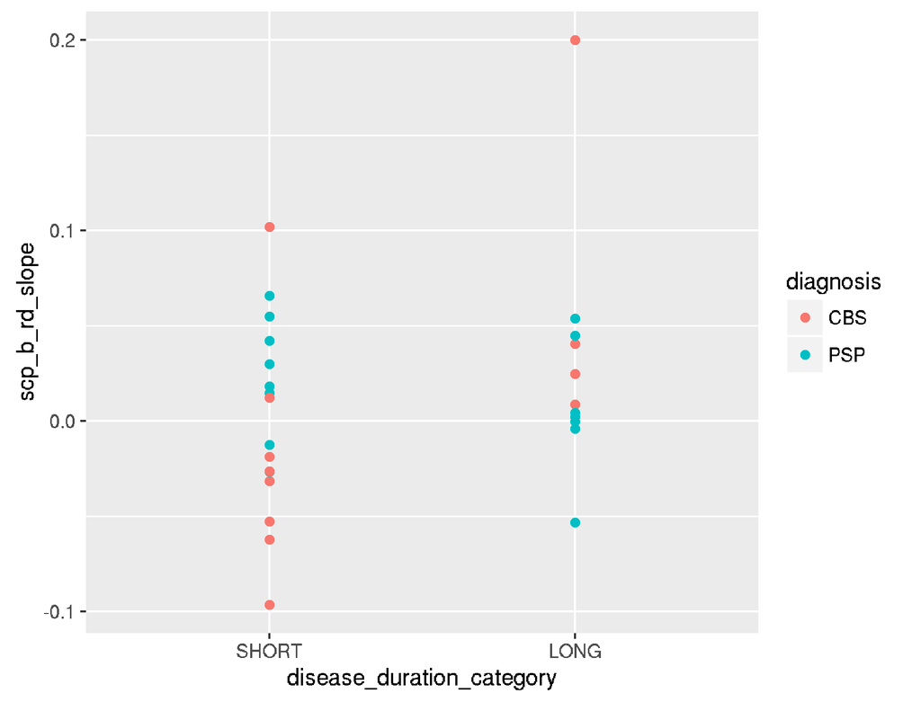

t.test for SHORT vs LONG group diff in slope among CBS: p=0.1330681

t.test for SHORT vs LONG group diff in slope among PSP: p=0.3633672

# Precentral Grey Matter Volume

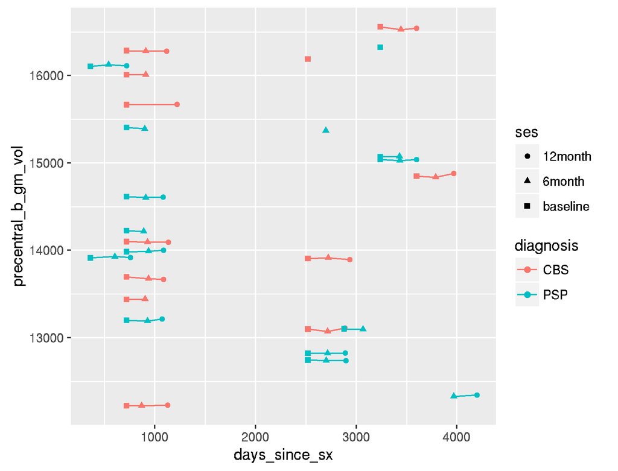

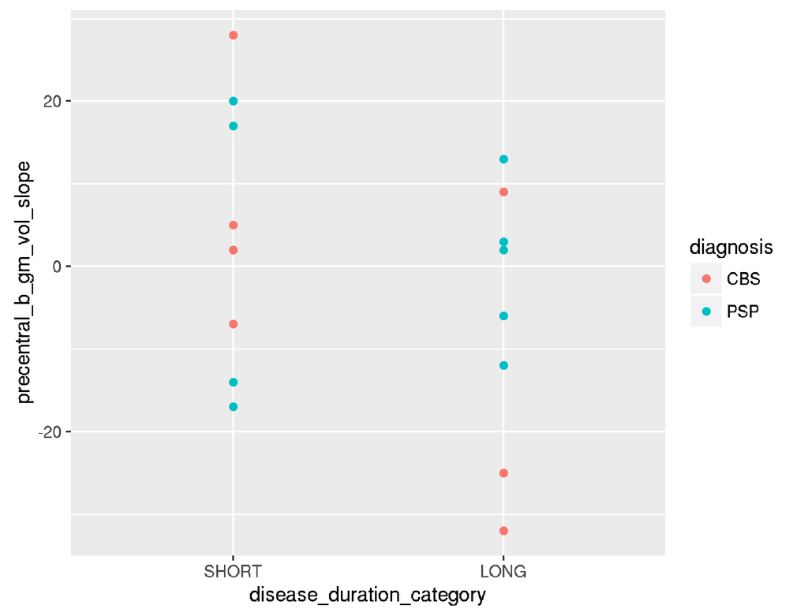

t.test for SHORT vs LONG group diff in slope among CBS: p=0.1172056

t.test for SHORT vs LONG group diff in slope among PSP: p=0.9514704

# Precentral Grey Matter Thickness

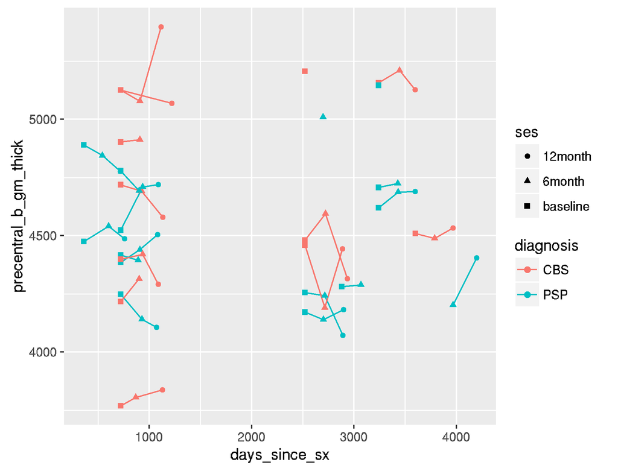

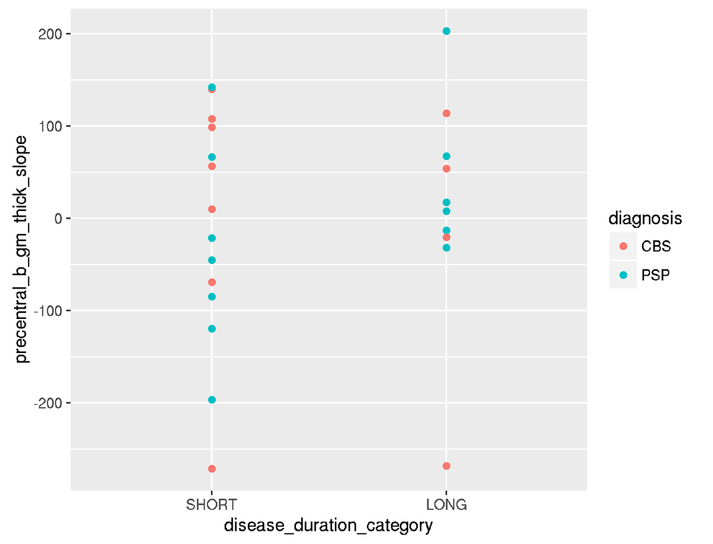

t.test for SHORT vs LONG group diff in slope among CBS: p=0.6999746

t.test for SHORT vs LONG group diff in slope among PSP: p=0.1831794

# Precentral White Matter Volume

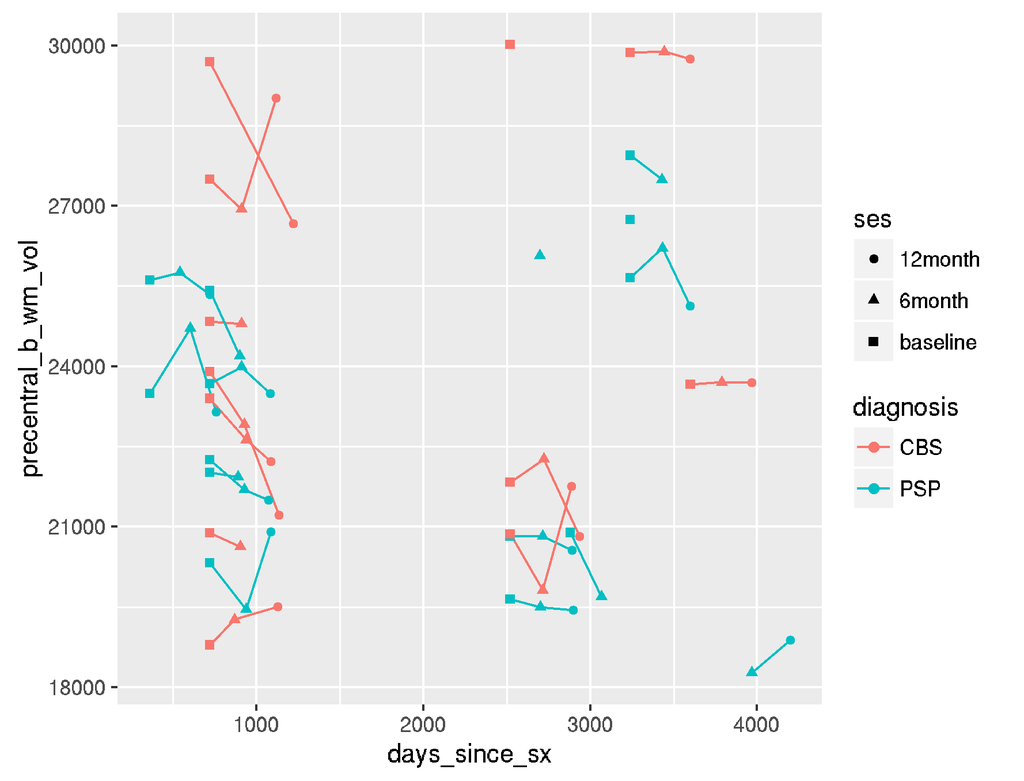

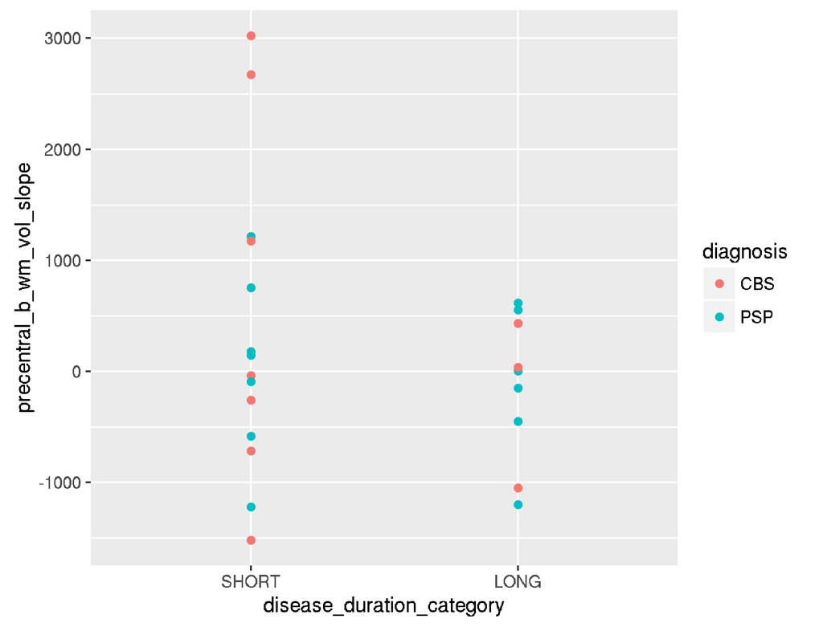

t.test for SHORT vs LONG group diff in slope among CBS: p=0.3245558

t.test for SHORT vs LONG group diff in slope among PSP: p=0.7017626

# Postcentral Grey Matter Volume

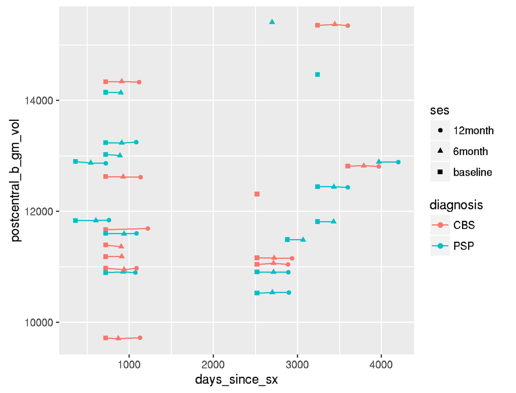

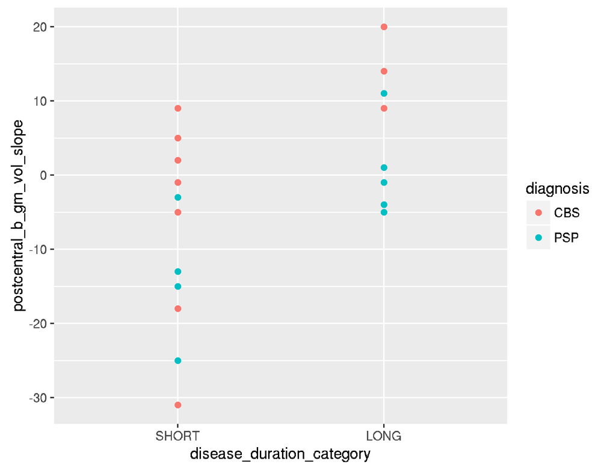

**t.test for SHORT vs LONG group diff in slope among CBS: p=0.04693535**

t.test for SHORT vs LONG group diff in slope among PSP: p=0.08225349

# Postcentral Grey Matter Thickness

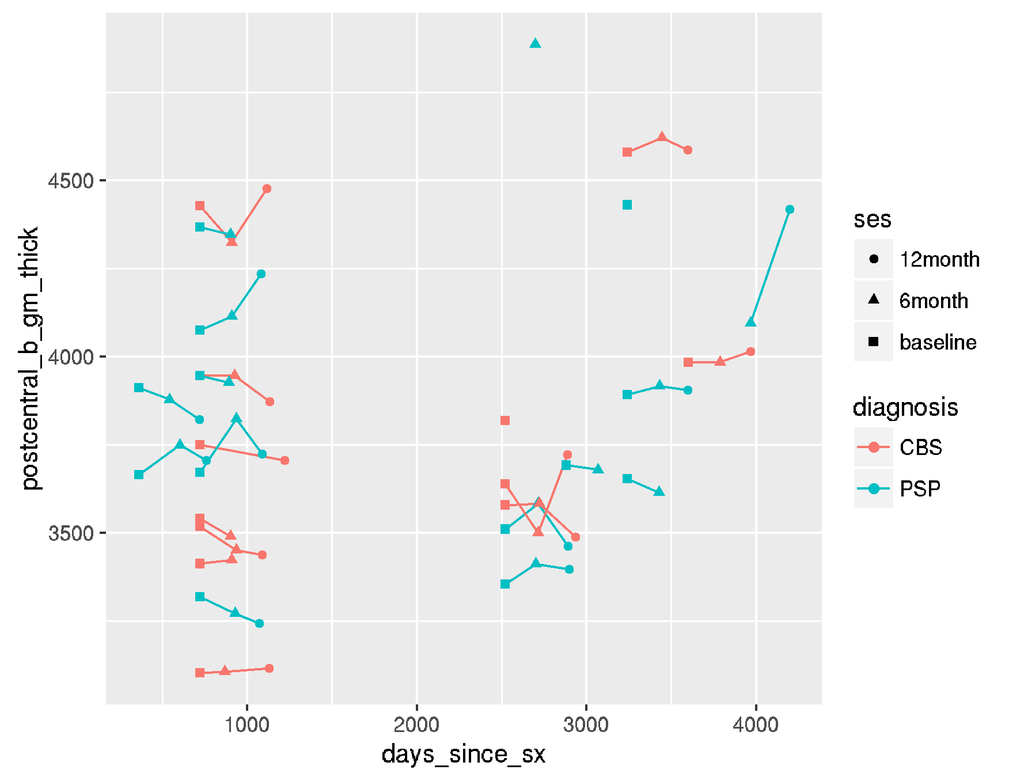

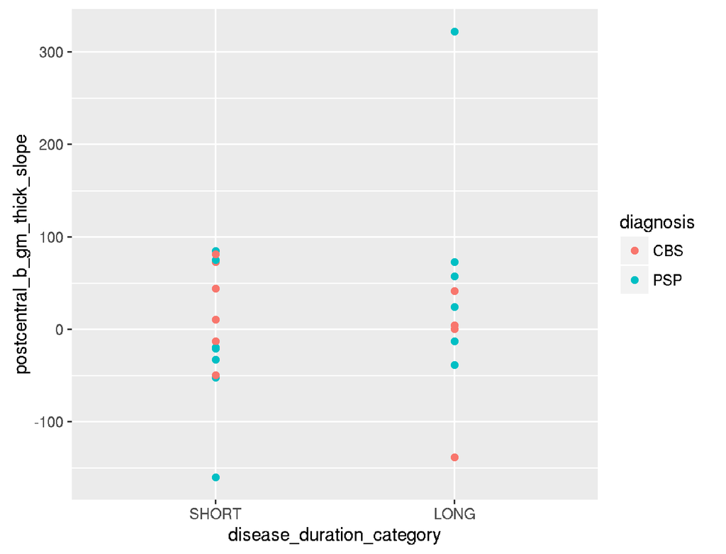

t.test for SHORT vs LONG group diff in slope among CBS: p=0.4506655

t.test for SHORT vs LONG group diff in slope among PSP: p=0.1860976